# **🌍 Global Analysis of Youth Mortality**

Author

**Manglesh Kumar**

Published

April 26, 2025

**Introduction**

Understanding the patterns of mortality among young adults is crucial for shaping global health policies and interventions. This analysis focuses specifically on deaths in the 20–24 age group, utilizing global data from 1990 to 2021. By examining geographical patterns, identifying countries with the highest burden, observing long-term trends, and exploring country-specific variations, we gain critical insights into youth health risks and areas requiring focused attention. The following visualizations aim to present these findings clearly and support evidence-based decision-making.

## Choropleth World Map of Deaths Aged 20–24

The choropleth map provides a global overview of deaths among individuals aged 20 to 24 years in 2021.  
Higher concentrations are observed in countries like India, Nigeria, and parts of Africa, highlighting regional disparities in youth mortality.  
This distribution reflects variations in healthcare access, education, socio-economic conditions, and public health systems across different regions.

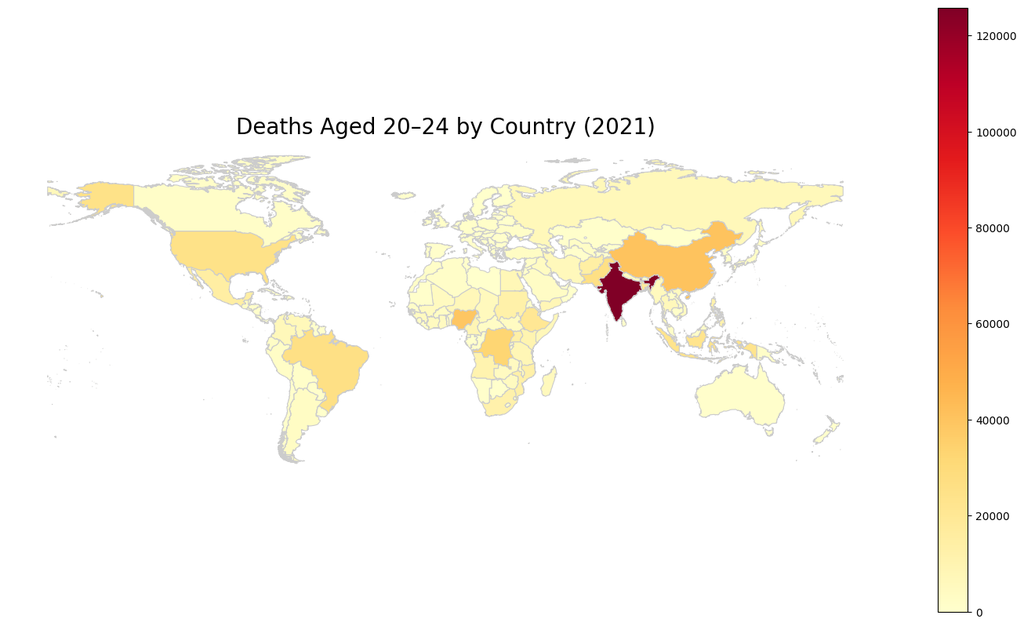

```python
import geopandas as gpd
import pandas as pd
import matplotlib.pyplot as plt
import seaborn as sns

map_data = pd.read_csv("indicator 1.csv")
map_data.columns = map_data.columns.str.strip()

map_filtered = map_data[(map_data['time_period'] == 2021) & (map_data['sex'] == 'Total')]

world = gpd.read_file("https://raw.githubusercontent.com/datasets/geo-countries/master/data/countries.geojson")

merged = world.merge(map_filtered, left_on='ISO3166-1-Alpha-3', right_on='alpha_3_code', how='left')

fig, ax = plt.subplots(1, 1, figsize=(18,10))
merged.plot(column='obs_value', cmap='YlOrRd', linewidth=0.8, ax=ax, edgecolor='0.8', legend=True)
plt.title('Deaths Aged 20–24 by Country (2021)', fontsize=20)
plt.axis('off')
plt.show()
```

## Top 10 Countries by Deaths (Bar Plot)

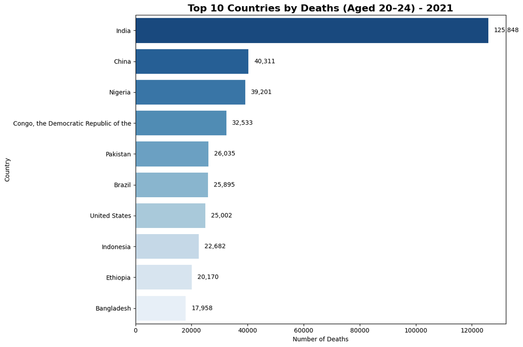

```python
top10 = (
    map_filtered
    .groupby('country')['obs_value']
    .sum()
    .sort_values(ascending=False)
    .head(10)
    .reset_index()
)

plt.figure(figsize=(12,8))
sns.barplot(data=top10, x='obs_value', y='country', palette='Blues_r')
for index, value in enumerate(top10['obs_value']):
    plt.text(value + 2000, index, f'{value:,}', va='center')
plt.title('Top 10 Countries by Deaths (Aged 20–24) - 2021', fontsize=16, weight='bold')
plt.xlabel('Number of Deaths')
plt.ylabel('Country')
plt.tight_layout()
plt.show()
```